# Project 2 Presentation

Reds Transactions

Hannah Dean

2024-11-11

# Intro

- I am analyzing the Cincinnati Reds transactions over the past 10 yrs.
- Resources: https://www.mlb.com/reds/roster/transactions
- Data: **Reds Transactions**

# Time Series Characteristics

- My data is tracking the number of transactions the Reds make each month on their 40-man roster.
  - signing
  - activating
  - trading
  - placing on IL
  - optioning
  - etc.
- There are a couple variables that could play a role in impacting the results of how many transactions there are each month:
  - the trade deadlines
  - the pre-season transactions
  - season injuries
  - etc.

# Decomposition Plot

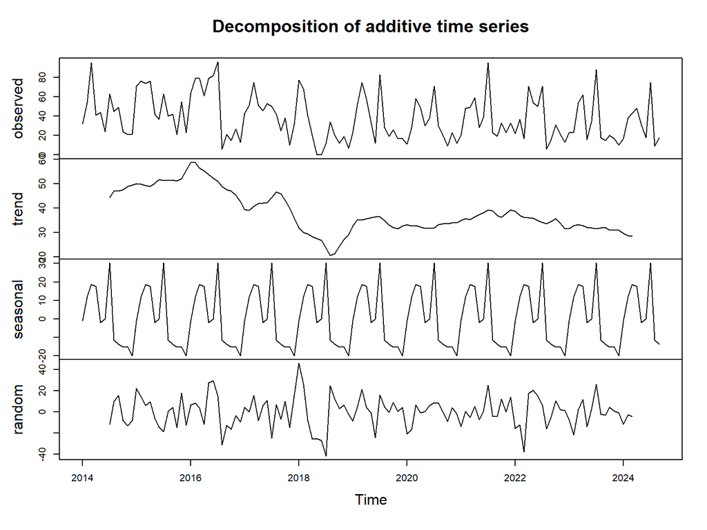

- Trend: There is slight decreasing trend in the data
- Seasonality: There is also yearly seasonality in the data

# Autocorrelation Function

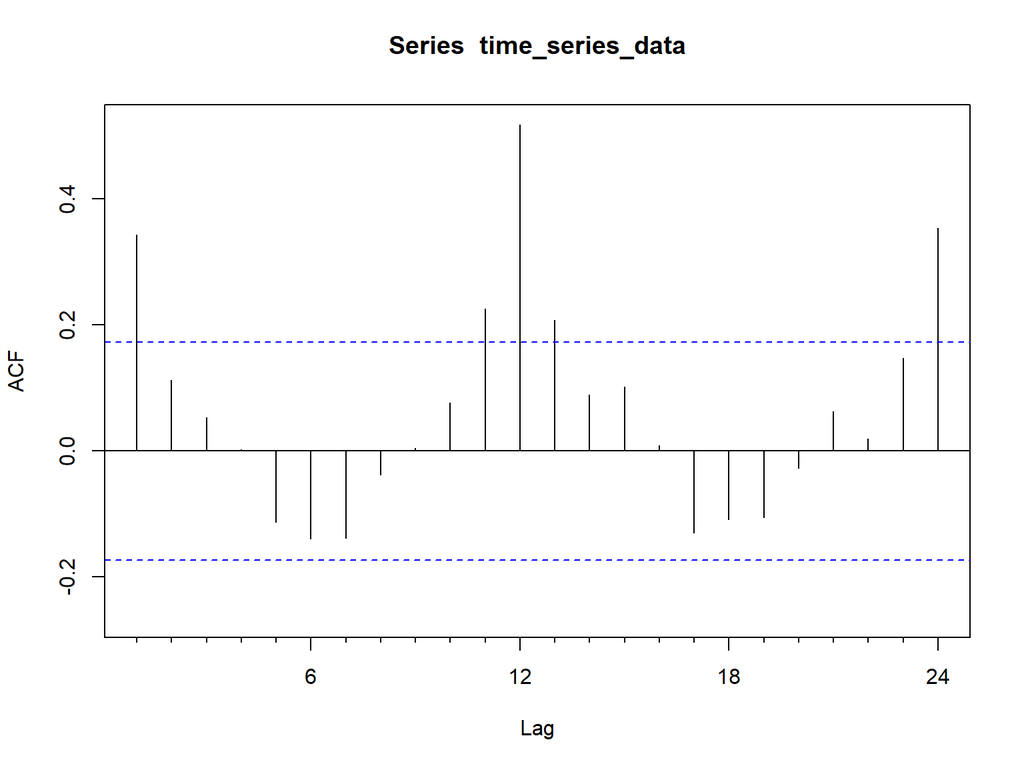

This shows us that there is significant yearly seasonality in the data due to the autocorrelation surpassing the bands.

# Decomposition Plot Continued

```
##
##  Augmented Dickey-Fuller Test
##
## data:  time_series_data
## Dickey-Fuller = -5.7796, Lag order = 5, p-value = 0.01
## alternative hypothesis: stationary
```

Because there is some trend and seasonality and because my data is stationary I decided to use the Holt-Winters Model

# Forecasting Model Choice (Holt Winter Model)

- I chose Exponential Smoothing because my data is stationary
- Out of all three exponential smoothing models I chose the Holt Winter Model because there is both seasonality and slight trend

# Slide 4: Model Results and Forecast Interpretation

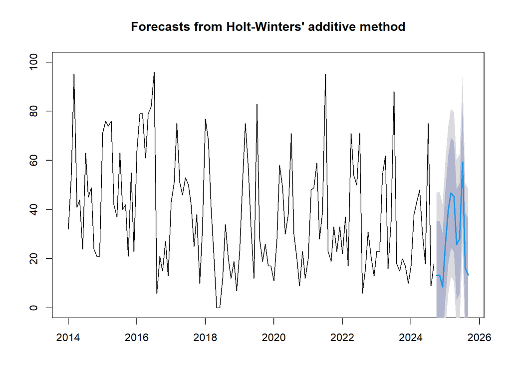

```
##          Point Forecast      Lo 80    Hi 80      Lo 95    Hi 95
## Oct 2024      13.326634  -8.628253 35.28152 -20.250468 46.90374
## Nov 2024      13.436938  -8.597156 35.47103 -20.261302 47.13518
## Dec 2024       8.491548 -13.621673 30.60477 -25.327706 42.31080
## Jan 2025      25.417877   3.225609 47.61014  -8.522268 59.35802
## Feb 2025      39.947481  17.676245 62.21872   5.886566 74.00840
## Mar 2025      46.835983  24.485858 69.18611  12.654416 81.01755
## Apr 2025      45.300763  22.871825 67.72970  10.998663 79.60286
## May 2025      25.881843   3.374168 48.38952  -8.540675 60.30436
## Jun 2025      28.137344   5.551007 50.72368  -6.405478 62.68017
## Jul 2025      59.377946  36.713020 82.04287  24.714933 94.04096
## Aug 2025      16.250544  -6.492897 38.99399 -18.532548 51.03364
## Sep 2025      13.417652  -9.404233 36.23954 -21.485410 48.32071
```

- My forecasted values show the same general trend in seasonality as my historical data however I would expect some of the numbers to have larger numbers than what was predicted.

# Slide 5: Model Diagnostics and Accuracy Evaluation

```
##                     ME     RMSE     MAE  MPE MAPE      MASE     ACF1
## Training set 0.1199806 16.03391 12.1033 -Inf  Inf 0.7076893 0.221398
```

```
##                     ME     RMSE      MAE  MPE MAPE     MASE      ACF1
## Training set -2.184319 22.98271 19.27862 -Inf  Inf 1.127236 0.2780426
```

```
##                      ME     RMSE      MAE  MPE MAPE     MASE     ACF1
## Training set -0.5805747 22.88994 18.79839 -Inf  Inf 1.099156 0.289916
```

- RMSE: Takes into consideration the large error variables in the prediction process therefore predictions could be off by 16 transactions a month
  - For Simple Exponential Smoothing and Holts Linear Model the predictions are off by 23 transactions a month
- MAE: Predictions are off by 12 transactions a month
  - For Simple Exponential Smoothing and Holts Linear Model the predictions are off by 20 transactions a month
- MASE: This model is more accurate than a naive model
  - For Simple Exponential Smoothing and Holts Linear Model the value for MASE surpasses 1 meaning that naive model would be more accurate
- ACF1: Little correlation in errors
  - For Simple Exponential Smoothing and Holts Linear Model correlation in errors is relitevely the same as the Holt Winters